# remove-false-positives

Andrew Edwards

2018-09-06

## Small example

The object `small_example` has one mock sample and three non-mock samples, with four absent species in the mock sample and three non-absent species. The first column identifies the sample, and remaining columns are a1, a2, a3 and a4 for the four absent species, and 1, 2 and 3 for the non-absent species. Corresponding entries are the number of reads of each species in each sample.

```r
library(eDNAcutoff)
```

```r
small_example
```

| Sample | a1 | a2 | a3 | a4 | 1 | 2 | 3 |
| --- | --- | --- | --- | --- | --- | --- | --- |
| mock | 257329 | 169668 | 79560 | 47859 | 53 | 17 | 12 |
| 1 | 17 | 7 | 9 | 6 | 42 | 17 | 61802 |
| 2 | 0 | 5 | 0 | 0 | 43997 | 10 | 17 |
| 3 | 0 | 0 | 0 | 0 | 26 | 1 | 22621 |

To remove the false positives use the function `remove_false_pos()`:

```r
small_removed <- remove_false_pos(small_example)
small_removed
```

| Sample | a1 | a2 | a3 | a4 | 1 | 2 | 3 |
| --- | --- | --- | --- | --- | --- | --- | --- |
| mock | 257329 | 169668 | 79560 | 47859 | 0 | 17 | 0 |
| 1 | 0 | 0 | 0 | 0 | 42 | 17 | 61802 |
| 2 | 0 | 0 | 0 | 0 | 43997 | 10 | 17 |
| 3 | 0 | 0 | 0 | 0 | 26 | 0 | 22621 |

To see which reads were set to zero use `which_set_to_zero()`:

```r
small_set_to_zero <- which_set_to_zero(small_example, small_removed)
small_set_to_zero
```

| Sample | a1 | a2 | a3 | a4 | 1 | 2 | 3 |
| --- | --- | --- | --- | --- | --- | --- | --- |
| mock | 0 | 0 | 0 | 0 | 53 | 0 | 12 |
| 1 | 17 | 7 | 9 | 6 | 0 | 0 | 0 |
| 2 | 0 | 5 | 0 | 0 | 0 | 0 | 0 |
| 3 | 0 | 0 | 0 | 0 | 0 | 1 | 0 |

To test sensitivity to $\alpha$ use the function `change_alpha()` for a vector of $\alpha$ values:

```r
alpha_values <- seq(0, 1, 0.1)
small_sens_alpha <- change_alpha(small_example, alpha.vec = alpha_values)
```

which returns a list containing:

- the number of reads set to zero (for each value of `alpha_values`)

```r
small_sens_alpha$num.zeroed
```

```
#>  [1]  4 12 12 12 12 12 13 13 13 13 15
```

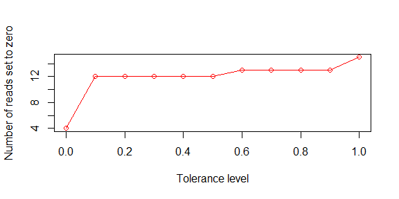

```r
plot(alpha_values, small_sens_alpha$num.zeroed,
     type = "o",
     col = "red",
     xlab = "Tolerance level",
     ylab = "Number of reads set to zero")
```

- the number of absent species left in non-mock samples (**check**)

```r
small_sens_alpha$num.mock.sp.left
```

```
#>  [1] 5 0 0 0 0 0 0 0 0 0 0
```

```r
small_sens_alpha$num.samp.rem.with.mock.sp
```

```
#>  [1] 2 0 0 0 0 0 0 0 0 0 0
```

- a data frame (tibble) for each value of `alpha_values`, for example

```r
alpha_values[6]
```

```
#> [1] 0.5
```

```r
small_sens_alpha$out.list[[6]]
```

| Sample | a1 | a2 | a3 | a4 | 1 | 2 | 3 |
| --- | --- | --- | --- | --- | --- | --- | --- |
| mock | 257329 | 169668 | 79560 | 47859 | 0 | 17 | 0 |
| 1 | 0 | 0 | 0 | 0 | 42 | 17 | 61802 |
| 2 | 0 | 0 | 0 | 0 | 43997 | 10 | 17 |
| 3 | 0 | 0 | 0 | 0 | 26 | 0 | 22621 |

and

```r
alpha_values[7]
```

```
#> [1] 0.6
```

```r
small_sens_alpha$out.list[[7]]
```

| Sample | a1 | a2 | a3 | a4 | 1 | 2 | 3 |
| --- | --- | --- | --- | --- | --- | --- | --- |
| mock | 257329 | 169668 | 79560 | 47859 | 0 | 17 | 0 |
| 1 | 0 | 0 | 0 | 0 | 42 | 17 | 61802 |
| 2 | 0 | 0 | 0 | 0 | 43997 | 0 | 17 |
| 3 | 0 | 0 | 0 | 0 | 26 | 0 | 22621 |

Note how the read of 10 for sample 2 and species 2 gets kept for $\alpha=0.5$ but zeroed for $\alpha=0.6$ (corresponding to the red line increasing up at $\alpha=0.6$ in the figure).

## Big example

```r
big_example
```

| Sample | a1 | a2 | a3 | a4 | 1 | 2 | 3 | 4 | 5 | 6 | 7 | 8 | 9 | 10 | 11 | 12 | 13 | 14 | 15 | 16 | 17 | 18 |
| --- | --- | --- | --- | --- | --- | --- | --- | --- | --- | --- | --- | --- | --- | --- | --- | --- | --- | --- | --- | --- | --- | --- |
| mock | 257329 | 169668 | 79560 | 47859 | 53 | 17 | 12 | 32 | 11 | 7 | 2 | 7 | 0 | 0 | 0 | 0 | 49 | 39 | 12 | 12 | 12 | 10 |
| 1 | 17 | 7 | 9 | 6 | 42 | 17 | 61802 | 7 | 10 | 1956 | 3 | 1 | 2 | 0 | 0 | 0 | 0 | 0 | 0 | 0 | 0 | 0 |
| 2 | 0 | 0 | 0 | 0 | 20941 | 43997 | 51031 | 4 | 7636 | 12171 | 4 | 0 | 4 | 0 | 0 | 0 | 0 | 0 | 0 | 0 | 0 | 0 |
| 3 | 0 | 0 | 0 | 0 | 26 | 26 | 22621 | 17845 | 7 | 50054 | 5 | 3 | 2417 | 0 | 0 | 0 | 0 | 0 | 0 | 0 | 0 | 0 |
| 4 | 0 | 0 | 0 | 0 | 36076 | 10 | 116718 | 2 | 5 | 9490 | 9 | 1 | 26 | 1 | 11 | 0 | 0 | 0 | 0 | 0 | 0 | 0 |
| 5 | 0 | 0 | 0 | 0 | 22 | 65969 | 1 | 8 | 8 | 6 | 0 | 0 | 0 | 0 | 0 | 0 | 0 | 0 | 0 | 0 | 0 | 0 |
| 6 | 0 | 0 | 0 | 0 | 21 | 36072 | 5 | 7 | 26845 | 4644 | 2 | 3 | 0 | 0 | 0 | 0 | 0 | 0 | 0 | 0 | 0 | 0 |
| 7 | 0 | 0 | 0 | 0 | 34416 | 23 | 126000 | 36 | 24517 | 16639 | 8 | 2 | 32 | 0 | 3 | 0 | 0 | 0 | 0 | 0 | 0 | 0 |
| 8 | 9 | 7 | 4 | 4 | 43 | 17 | 3 | 12 | 18099 | 2 | 3 | 2 | 0 | 0 | 0 | 0 | 0 | 0 | 0 | 0 | 0 | 0 |
| 9 | 0 | 0 | 0 | 0 | 39009 | 50 | 64766 | 27 | 25 | 54089 | 16 | 12 | 5 | 0 | 0 | 0 | 0 | 0 | 0 | 0 | 0 | 0 |
| 10 | 0 | 0 | 0 | 0 | 29 | 37275 | 44153 | 7 | 8 | 10791 | 15 | 0 | 0 | 0 | 0 | 0 | 0 | 0 | 0 | 0 | 0 | 0 |
| 11 | 0 | 0 | 0 | 0 | 38660 | 16689 | 41995 | 51 | 13 | 34527 | 31388 | 17960 | 0 | 0 | 0 | 0 | 0 | 0 | 0 | 0 | 0 | 0 |
| 12 | 0 | 0 | 0 | 0 | 217 | 81 | 145052 | 51 | 32 | 2177 | 53 | 22 | 2 | 0 | 0 | 0 | 0 | 0 | 0 | 0 | 0 | 0 |
| 13 | 0 | 0 | 0 | 0 | 10 | 39 | 62409 | 6 | 4 | 16812 | 10 | 0 | 1 | 0 | 1 | 0 | 0 | 0 | 0 | 0 | 0 | 0 |
| 14 | 7 | 23 | 15 | 5 | 23136 | 16 | 71566 | 4 | 3 | 1919 | 2 | 0 | 0 | 0 | 0 | 0 | 0 | 0 | 0 | 0 | 0 | 0 |
| 15 | 0 | 0 | 0 | 0 | 3128 | 16 | 3412 | 9 | 9 | 151260 | 2 | 3 | 0 | 0 | 0 | 0 | 0 | 0 | 0 | 0 | 0 | 0 |
| 16 | 0 | 0 | 0 | 0 | 2 | 5 | 40996 | 0 | 7 | 1540 | 2 | 0 | 0 | 0 | 0 | 0 | 0 | 0 | 0 | 0 | 0 | 0 |
| 17 | 0 | 0 | 0 | 0 | 16980 | 23369 | 16 | 3 | 50995 | 32191 | 2 | 0 | 0 | 0 | 0 | 0 | 0 | 0 | 0 | 0 | 0 | 0 |
| 18 | 0 | 0 | 0 | 0 | 25 | 19307 | 98698 | 7 | 10863 | 29452 | 8 | 5 | 3 | 0 | 0 | 0 | 0 | 0 | 0 | 0 | 0 | 0 |
| 19 | 0 | 0 | 0 | 0 | 21384 | 18966 | 10 | 0 | 24375 | 16187 | 1 | 1 | 1 | 0 | 0 | 0 | 0 | 0 | 0 | 0 | 0 | 0 |
| 20 | 0 | 0 | 0 | 0 | 5 | 5994 | 4813 | 0 | 1 | 876 | 0 | 1 | 1 | 0 | 0 | 0 | 0 | 0 | 0 | 0 | 0 | 0 |
| 21 | 0 | 0 | 0 | 0 | 102218 | 28873 | 22 | 24342 | 14847 | 23049 | 65259 | 11 | 0 | 0 | 0 | 0 | 0 | 0 | 0 | 0 | 0 | 0 |
| 22 | 2 | 13 | 2 | 9 | 13041 | 7361 | 2 | 4367 | 0 | 4981 | 7168 | 0 | 1 | 0 | 0 | 0 | 0 | 0 | 0 | 0 | 0 | 0 |
| 23 | 0 | 0 | 0 | 0 | 43531 | 85891 | 19 | 15748 | 16605 | 22672 | 12 | 47302 | 7 | 0 | 0 | 0 | 0 | 0 | 0 | 0 | 0 | 0 |
| 24 | 0 | 0 | 0 | 0 | 42358 | 41127 | 7 | 5 | 4 | 11 | 5 | 1 | 4 | 0 | 0 | 0 | 0 | 0 | 0 | 0 | 0 | 0 |
| 25 | 0 | 0 | 0 | 0 | 55241 | 1369 | 639 | 11854 | 10275 | 10124 | 55453 | 3 | 0 | 0 | 0 | 0 | 0 | 0 | 0 | 0 | 0 | 0 |
| 26 | 20 | 40 | 31 | 10 | 190272 | 9756 | 32 | 15947 | 85960 | 74217 | 22497 | 13 | 1 | 0 | 0 | 0 | 0 | 0 | 0 | 0 | 0 | 0 |
| 27 | 0 | 0 | 0 | 0 | 116880 | 109320 | 19 | 33889 | 5770 | 1423 | 10571 | 5913 | 3 | 0 | 0 | 0 | 0 | 0 | 0 | 0 | 0 | 0 |
| 28 | 0 | 0 | 0 | 0 | 414 | 63 | 24052 | 23 | 31 | 783 | 12 | 4 | 2 | 0 | 0 | 0 | 0 | 0 | 0 | 0 | 0 | 0 |
| 29 | 0 | 0 | 0 | 0 | 181768 | 1573 | 1358 | 4727 | 12113 | 16820 | 10241 | 11 | 0 | 0 | 1 | 0 | 0 | 0 | 0 | 0 | 0 | 0 |

[output cut: 95 more lines]

To remove the false positives:

```r
big_removed <- remove_false_pos(big_example)
big_removed
```

| Sample | a1 | a2 | a3 | a4 | 1 | 2 | 3 | 4 | 5 | 6 | 7 | 8 | 9 | 10 | 11 | 12 | 13 | 14 | 15 | 16 | 17 | 18 |
| --- | --- | --- | --- | --- | --- | --- | --- | --- | --- | --- | --- | --- | --- | --- | --- | --- | --- | --- | --- | --- | --- | --- |
| mock | 257329 | 169668 | 79560 | 47859 | 0 | 0 | 0 | 0 | 0 | 0 | 0 | 0 | 0 | 0 | 0 | 0 | 49 | 39 | 12 | 12 | 12 | 10 |
| 1 | 17 | 0 | 0 | 0 | 42 | 17 | 61802 | 0 | 0 | 1956 | 0 | 0 | 0 | 0 | 0 | 0 | 0 | 0 | 0 | 0 | 0 | 0 |
| 2 | 0 | 0 | 0 | 0 | 20941 | 43997 | 51031 | 0 | 7636 | 12171 | 0 | 0 | 0 | 0 | 0 | 0 | 0 | 0 | 0 | 0 | 0 | 0 |
| 3 | 0 | 0 | 0 | 0 | 26 | 26 | 22621 | 17845 | 0 | 50054 | 0 | 0 | 2417 | 0 | 0 | 0 | 0 | 0 | 0 | 0 | 0 | 0 |
| 4 | 0 | 0 | 0 | 0 | 36076 | 0 | 116718 | 0 | 0 | 9490 | 0 | 0 | 0 | 0 | 0 | 0 | 0 | 0 | 0 | 0 | 0 | 0 |
| 5 | 0 | 0 | 0 | 0 | 22 | 65969 | 0 | 0 | 0 | 0 | 0 | 0 | 0 | 0 | 0 | 0 | 0 | 0 | 0 | 0 | 0 | 0 |
| 6 | 0 | 0 | 0 | 0 | 21 | 36072 | 0 | 0 | 26845 | 4644 | 0 | 0 | 0 | 0 | 0 | 0 | 0 | 0 | 0 | 0 | 0 | 0 |
| 7 | 0 | 0 | 0 | 0 | 34416 | 0 | 126000 | 0 | 24517 | 16639 | 0 | 0 | 0 | 0 | 0 | 0 | 0 | 0 | 0 | 0 | 0 | 0 |
| 8 | 9 | 7 | 4 | 4 | 43 | 17 | 0 | 12 | 18099 | 0 | 0 | 0 | 0 | 0 | 0 | 0 | 0 | 0 | 0 | 0 | 0 | 0 |
| 9 | 0 | 0 | 0 | 0 | 39009 | 50 | 64766 | 0 | 0 | 54089 | 0 | 0 | 0 | 0 | 0 | 0 | 0 | 0 | 0 | 0 | 0 | 0 |
| 10 | 0 | 0 | 0 | 0 | 29 | 37275 | 44153 | 0 | 0 | 10791 | 0 | 0 | 0 | 0 | 0 | 0 | 0 | 0 | 0 | 0 | 0 | 0 |
| 11 | 0 | 0 | 0 | 0 | 38660 | 16689 | 41995 | 51 | 0 | 34527 | 31388 | 17960 | 0 | 0 | 0 | 0 | 0 | 0 | 0 | 0 | 0 | 0 |
| 12 | 0 | 0 | 0 | 0 | 217 | 81 | 145052 | 51 | 32 | 2177 | 53 | 0 | 0 | 0 | 0 | 0 | 0 | 0 | 0 | 0 | 0 | 0 |
| 13 | 0 | 0 | 0 | 0 | 0 | 39 | 62409 | 0 | 0 | 16812 | 0 | 0 | 0 | 0 | 0 | 0 | 0 | 0 | 0 | 0 | 0 | 0 |
| 14 | 0 | 23 | 0 | 0 | 23136 | 0 | 71566 | 0 | 0 | 1919 | 0 | 0 | 0 | 0 | 0 | 0 | 0 | 0 | 0 | 0 | 0 | 0 |
| 15 | 0 | 0 | 0 | 0 | 3128 | 0 | 3412 | 0 | 0 | 151260 | 0 | 0 | 0 | 0 | 0 | 0 | 0 | 0 | 0 | 0 | 0 | 0 |
| 16 | 0 | 0 | 0 | 0 | 0 | 0 | 40996 | 0 | 0 | 1540 | 0 | 0 | 0 | 0 | 0 | 0 | 0 | 0 | 0 | 0 | 0 | 0 |
| 17 | 0 | 0 | 0 | 0 | 16980 | 23369 | 0 | 0 | 50995 | 32191 | 0 | 0 | 0 | 0 | 0 | 0 | 0 | 0 | 0 | 0 | 0 | 0 |
| 18 | 0 | 0 | 0 | 0 | 0 | 19307 | 98698 | 0 | 10863 | 29452 | 0 | 0 | 0 | 0 | 0 | 0 | 0 | 0 | 0 | 0 | 0 | 0 |
| 19 | 0 | 0 | 0 | 0 | 21384 | 18966 | 0 | 0 | 24375 | 16187 | 0 | 0 | 0 | 0 | 0 | 0 | 0 | 0 | 0 | 0 | 0 | 0 |
| 20 | 0 | 0 | 0 | 0 | 5 | 5994 | 4813 | 0 | 0 | 876 | 0 | 0 | 0 | 0 | 0 | 0 | 0 | 0 | 0 | 0 | 0 | 0 |
| 21 | 0 | 0 | 0 | 0 | 102218 | 28873 | 0 | 24342 | 14847 | 23049 | 65259 | 0 | 0 | 0 | 0 | 0 | 0 | 0 | 0 | 0 | 0 | 0 |
| 22 | 0 | 13 | 0 | 9 | 13041 | 7361 | 0 | 4367 | 0 | 4981 | 7168 | 0 | 0 | 0 | 0 | 0 | 0 | 0 | 0 | 0 | 0 | 0 |
| 23 | 0 | 0 | 0 | 0 | 43531 | 85891 | 0 | 15748 | 16605 | 22672 | 0 | 47302 | 0 | 0 | 0 | 0 | 0 | 0 | 0 | 0 | 0 | 0 |
| 24 | 0 | 0 | 0 | 0 | 42358 | 41127 | 0 | 0 | 0 | 0 | 0 | 0 | 0 | 0 | 0 | 0 | 0 | 0 | 0 | 0 | 0 | 0 |
| 25 | 0 | 0 | 0 | 0 | 55241 | 1369 | 639 | 11854 | 10275 | 10124 | 55453 | 0 | 0 | 0 | 0 | 0 | 0 | 0 | 0 | 0 | 0 | 0 |
| 26 | 0 | 0 | 0 | 0 | 190272 | 9756 | 0 | 15947 | 85960 | 74217 | 22497 | 0 | 0 | 0 | 0 | 0 | 0 | 0 | 0 | 0 | 0 | 0 |
| 27 | 0 | 0 | 0 | 0 | 116880 | 109320 | 0 | 33889 | 5770 | 1423 | 10571 | 5913 | 0 | 0 | 0 | 0 | 0 | 0 | 0 | 0 | 0 | 0 |
| 28 | 0 | 0 | 0 | 0 | 414 | 63 | 24052 | 23 | 31 | 783 | 12 | 0 | 0 | 0 | 0 | 0 | 0 | 0 | 0 | 0 | 0 | 0 |
| 29 | 0 | 0 | 0 | 0 | 181768 | 1573 | 1358 | 4727 | 12113 | 16820 | 10241 | 0 | 0 | 0 | 0 | 0 | 0 | 0 | 0 | 0 | 0 | 0 |

[output cut: 95 more lines]

And again, to see which reads were set to zero use `which_set_to_zero()`:

```r
big_set_to_zero <- which_set_to_zero(big_example, big_removed)
big_set_to_zero
```

| Sample | a1 | a2 | a3 | a4 | 1 | 2 | 3 | 4 | 5 | 6 | 7 | 8 | 9 | 10 | 11 | 12 | 13 | 14 | 15 | 16 | 17 | 18 |
| --- | --- | --- | --- | --- | --- | --- | --- | --- | --- | --- | --- | --- | --- | --- | --- | --- | --- | --- | --- | --- | --- | --- |
| mock | 0 | 0 | 0 | 0 | 53 | 17 | 12 | 32 | 11 | 7 | 2 | 7 | 0 | 0 | 0 | 0 | 0 | 0 | 0 | 0 | 0 | 0 |
| 1 | 0 | 7 | 9 | 6 | 0 | 0 | 0 | 7 | 10 | 0 | 3 | 1 | 2 | 0 | 0 | 0 | 0 | 0 | 0 | 0 | 0 | 0 |
| 2 | 0 | 0 | 0 | 0 | 0 | 0 | 0 | 4 | 0 | 0 | 4 | 0 | 4 | 0 | 0 | 0 | 0 | 0 | 0 | 0 | 0 | 0 |
| 3 | 0 | 0 | 0 | 0 | 0 | 0 | 0 | 0 | 7 | 0 | 5 | 3 | 0 | 0 | 0 | 0 | 0 | 0 | 0 | 0 | 0 | 0 |
| 4 | 0 | 0 | 0 | 0 | 0 | 10 | 0 | 2 | 5 | 0 | 9 | 1 | 26 | 1 | 11 | 0 | 0 | 0 | 0 | 0 | 0 | 0 |
| 5 | 0 | 0 | 0 | 0 | 0 | 0 | 1 | 8 | 8 | 6 | 0 | 0 | 0 | 0 | 0 | 0 | 0 | 0 | 0 | 0 | 0 | 0 |
| 6 | 0 | 0 | 0 | 0 | 0 | 0 | 5 | 7 | 0 | 0 | 2 | 3 | 0 | 0 | 0 | 0 | 0 | 0 | 0 | 0 | 0 | 0 |
| 7 | 0 | 0 | 0 | 0 | 0 | 23 | 0 | 36 | 0 | 0 | 8 | 2 | 32 | 0 | 3 | 0 | 0 | 0 | 0 | 0 | 0 | 0 |
| 8 | 0 | 0 | 0 | 0 | 0 | 0 | 3 | 0 | 0 | 2 | 3 | 2 | 0 | 0 | 0 | 0 | 0 | 0 | 0 | 0 | 0 | 0 |
| 9 | 0 | 0 | 0 | 0 | 0 | 0 | 0 | 27 | 25 | 0 | 16 | 12 | 5 | 0 | 0 | 0 | 0 | 0 | 0 | 0 | 0 | 0 |
| 10 | 0 | 0 | 0 | 0 | 0 | 0 | 0 | 7 | 8 | 0 | 15 | 0 | 0 | 0 | 0 | 0 | 0 | 0 | 0 | 0 | 0 | 0 |
| 11 | 0 | 0 | 0 | 0 | 0 | 0 | 0 | 0 | 13 | 0 | 0 | 0 | 0 | 0 | 0 | 0 | 0 | 0 | 0 | 0 | 0 | 0 |
| 12 | 0 | 0 | 0 | 0 | 0 | 0 | 0 | 0 | 0 | 0 | 0 | 22 | 2 | 0 | 0 | 0 | 0 | 0 | 0 | 0 | 0 | 0 |
| 13 | 0 | 0 | 0 | 0 | 10 | 0 | 0 | 6 | 4 | 0 | 10 | 0 | 1 | 0 | 1 | 0 | 0 | 0 | 0 | 0 | 0 | 0 |
| 14 | 7 | 0 | 15 | 5 | 0 | 16 | 0 | 4 | 3 | 0 | 2 | 0 | 0 | 0 | 0 | 0 | 0 | 0 | 0 | 0 | 0 | 0 |
| 15 | 0 | 0 | 0 | 0 | 0 | 16 | 0 | 9 | 9 | 0 | 2 | 3 | 0 | 0 | 0 | 0 | 0 | 0 | 0 | 0 | 0 | 0 |
| 16 | 0 | 0 | 0 | 0 | 2 | 5 | 0 | 0 | 7 | 0 | 2 | 0 | 0 | 0 | 0 | 0 | 0 | 0 | 0 | 0 | 0 | 0 |
| 17 | 0 | 0 | 0 | 0 | 0 | 0 | 16 | 3 | 0 | 0 | 2 | 0 | 0 | 0 | 0 | 0 | 0 | 0 | 0 | 0 | 0 | 0 |
| 18 | 0 | 0 | 0 | 0 | 25 | 0 | 0 | 7 | 0 | 0 | 8 | 5 | 3 | 0 | 0 | 0 | 0 | 0 | 0 | 0 | 0 | 0 |
| 19 | 0 | 0 | 0 | 0 | 0 | 0 | 10 | 0 | 0 | 0 | 1 | 1 | 1 | 0 | 0 | 0 | 0 | 0 | 0 | 0 | 0 | 0 |
| 20 | 0 | 0 | 0 | 0 | 0 | 0 | 0 | 0 | 1 | 0 | 0 | 1 | 1 | 0 | 0 | 0 | 0 | 0 | 0 | 0 | 0 | 0 |
| 21 | 0 | 0 | 0 | 0 | 0 | 0 | 22 | 0 | 0 | 0 | 0 | 11 | 0 | 0 | 0 | 0 | 0 | 0 | 0 | 0 | 0 | 0 |
| 22 | 2 | 0 | 2 | 0 | 0 | 0 | 2 | 0 | 0 | 0 | 0 | 0 | 1 | 0 | 0 | 0 | 0 | 0 | 0 | 0 | 0 | 0 |
| 23 | 0 | 0 | 0 | 0 | 0 | 0 | 19 | 0 | 0 | 0 | 12 | 0 | 7 | 0 | 0 | 0 | 0 | 0 | 0 | 0 | 0 | 0 |
| 24 | 0 | 0 | 0 | 0 | 0 | 0 | 7 | 5 | 4 | 11 | 5 | 1 | 4 | 0 | 0 | 0 | 0 | 0 | 0 | 0 | 0 | 0 |
| 25 | 0 | 0 | 0 | 0 | 0 | 0 | 0 | 0 | 0 | 0 | 0 | 3 | 0 | 0 | 0 | 0 | 0 | 0 | 0 | 0 | 0 | 0 |
| 26 | 20 | 40 | 31 | 10 | 0 | 0 | 32 | 0 | 0 | 0 | 0 | 13 | 1 | 0 | 0 | 0 | 0 | 0 | 0 | 0 | 0 | 0 |
| 27 | 0 | 0 | 0 | 0 | 0 | 0 | 19 | 0 | 0 | 0 | 0 | 0 | 3 | 0 | 0 | 0 | 0 | 0 | 0 | 0 | 0 | 0 |
| 28 | 0 | 0 | 0 | 0 | 0 | 0 | 0 | 0 | 0 | 0 | 0 | 4 | 2 | 0 | 0 | 0 | 0 | 0 | 0 | 0 | 0 | 0 |
| 29 | 0 | 0 | 0 | 0 | 0 | 0 | 0 | 0 | 0 | 0 | 0 | 11 | 0 | 0 | 1 | 0 | 0 | 0 | 0 | 0 | 0 | 0 |

[output cut: 95 more lines]

**To test sensitivity to** $\alpha$, **do as above (but just plot the results here)**

As above, to test sensitivity to $\alpha$:

```r
big_sens_alpha <- change_alpha(big_example, alpha.vec = alpha_values)
```

which returns a list containing:

- the number of reads set to zero (for each value of `alpha_values`)

```r
big_sens_alpha$num.zeroed
```

```
#>  [1] 125 493 493 493 493 493 493 493 493 493 499
```

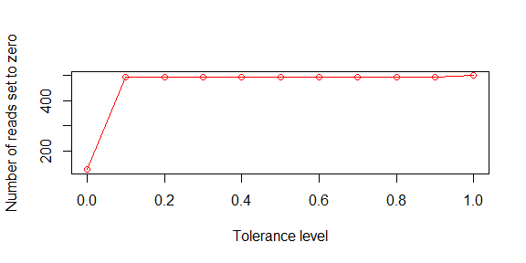

```r
plot(alpha_values, big_sens_alpha$num.zeroed,
     type = "o",
     col = "red",
     xlab = "Tolerance level",
     ylab = "Number of reads set to zero")
```

- the number of absent species left in non-mock samples (**check**)

```r
big_sens_alpha$num.mock.sp.left
```

```
#>  [1] 57 13 13 13 13 13 13 13 13 13 13
```

```r
big_sens_alpha$num.samp.rem.with.mock.sp
```

```
#>  [1] 16  7  7  7  7  7  7  7  7  7  7
```

- a data frame (tibble) for each value of `alpha_values` available as `big_sens_alpha$out.list[[6]]` etc. (not shown).

**TODO** Seems surprising that the big data set is fairly insensitive to $\alpha$ - look into somewhat manually and check. And set up a `test()`.